# ISTA 320 Spring 2021 Final Project

Tingting Thompson

Spring 2021

```r
library(knitr)
library(tidyverse)
opts_chunk$set(echo = TRUE, message = FALSE)
```

Data Description: These data comes from yahoo finance historical data which can be found at https://finance.yahoo.com/ or can be accessed via Python and the yahoo finance library yfinance. Because this data set spans only seven days, a daily price history was not useful which is the lowest interval provided on the yahoo finance website directly. I was able to collect hourly pricing data for each stock using the yfinance and in accordance with pandas was able to export it to csv files. This process was executed using the ToCSV.py script which can be found in this current working directory. Each CSV has seven total variables: Date, Opening Price, Hourly High, Hourly Low, Closing Price, Adjusted Closing Price, and Volume. Once again, to emphasize, each of these prices were in the context of an hourly interval.

```r
GME <- read_csv("GME.csv")
AMC <- read_csv("AMC.csv")
```

At this point I was unable to authorize the use of twitteR function searchTwitter due to developer account approval issues.

```r
#gamestonks <- searchTwitter("gamestonk", since = "2021-01-25", until = "2021-02-02")
```

Clean and Adjust Data: For the most part, the data was already tidy. For other purposes, I derived variables such as the hour since the first hour, the average price for the hour based on the high and low, as well as percent changes in price based on the very first hour’s price. The purpose of the percent was because the prices for GME were far greater than that of AMC. A final df was produced combining the two by rows and adding a Stock variable to label each instance by the stock name.

```r
GME$Hour <- as.numeric(rownames(GME))
AMC$Hour <- as.numeric(rownames(AMC))
GME$Avg_Price <- (GME$High + GME$Low)/2
AMC$Avg_Price <- (AMC$High + AMC$Low)/2
GMEFirstPrice <- GME$Avg_Price[which(GME$Hour == 1)]
GME$Perc_Change_Avg_Price <- 100 * (GME$Avg_Price - GMEFirstPrice)/ GMEFirstPrice
AMCFirstPrice <- AMC$Avg_Price[which(AMC$Hour == 1)]
AMC$Perc_Change_Avg_Price <- 100 * (AMC$Avg_Price - AMCFirstPrice)/ AMCFirstPrice
GME$Stock <- "GME"
AMC$Stock <- "AMC"

df <- rbind(GME, AMC)
```

Line graph of Share Price over Time:

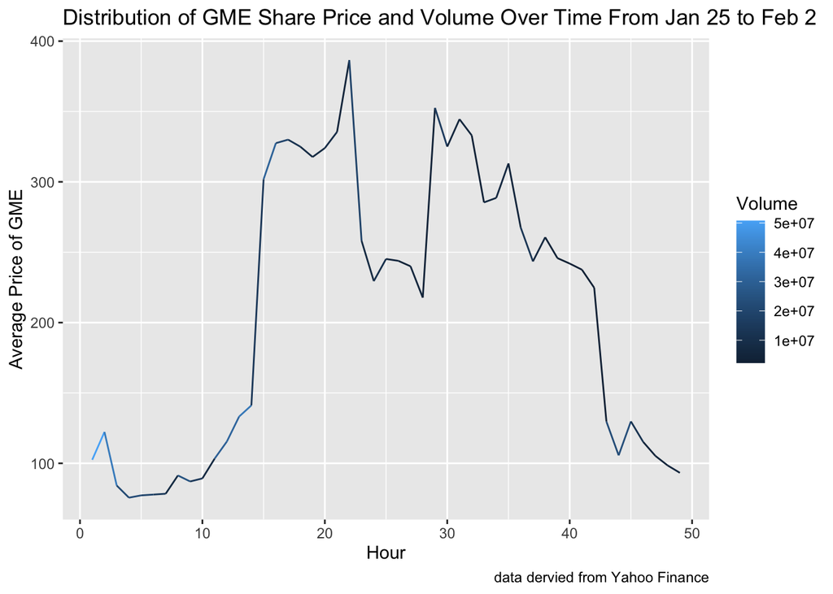

```r
df %>%
  filter(Stock == "GME") %>%
  ggplot(aes(x= Hour,
             y = Avg_Price,
             color = Volume)) +
  geom_line() +
  labs(y = "Average Price of GME",
       x = "Hour",
       fill = "Volume",
       title = "Distribution of GME Share Price and Volume Over Time From Jan 25 to Feb 2",
       caption = "data dervied from Yahoo Finance")
```

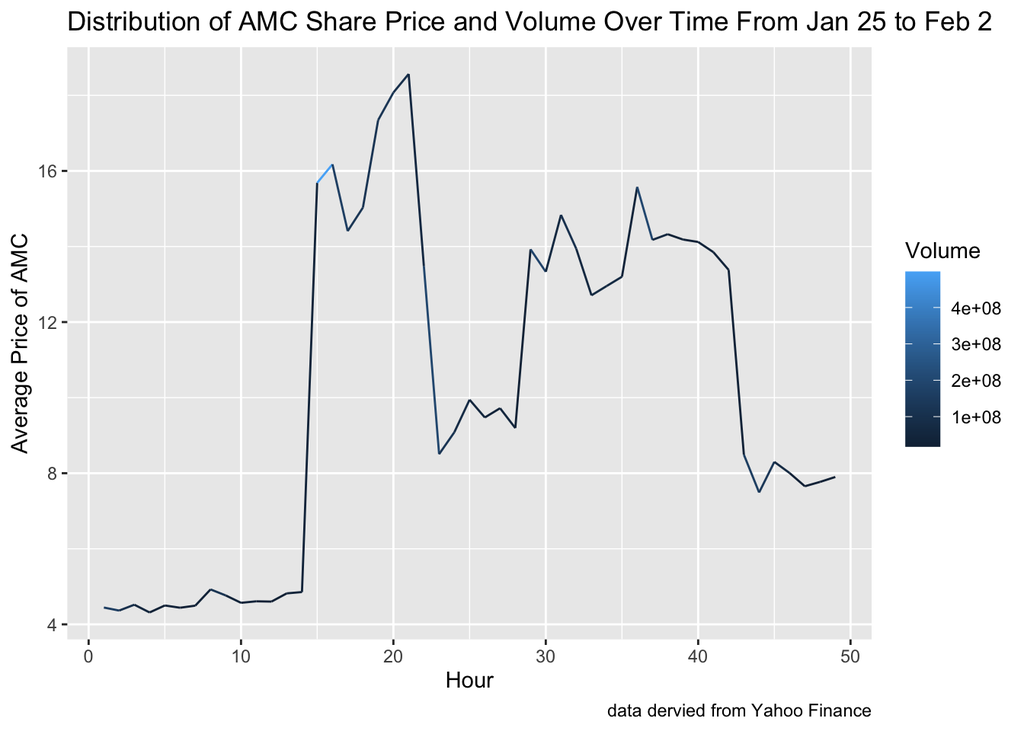

```r
df %>%
  filter(Stock == "AMC") %>%
  ggplot(aes(x= Hour,
             y = Avg_Price,
             color = Volume)) +
  geom_line() +
  labs(y = "Average Price of AMC",
       x = "Hour",
       fill = "Volume",
       title = "Distribution of AMC Share Price and Volume Over Time From Jan 25 to Feb 2",
       caption = "data dervied from Yahoo Finance")
```

Comparative Bar plot of Daily Price:

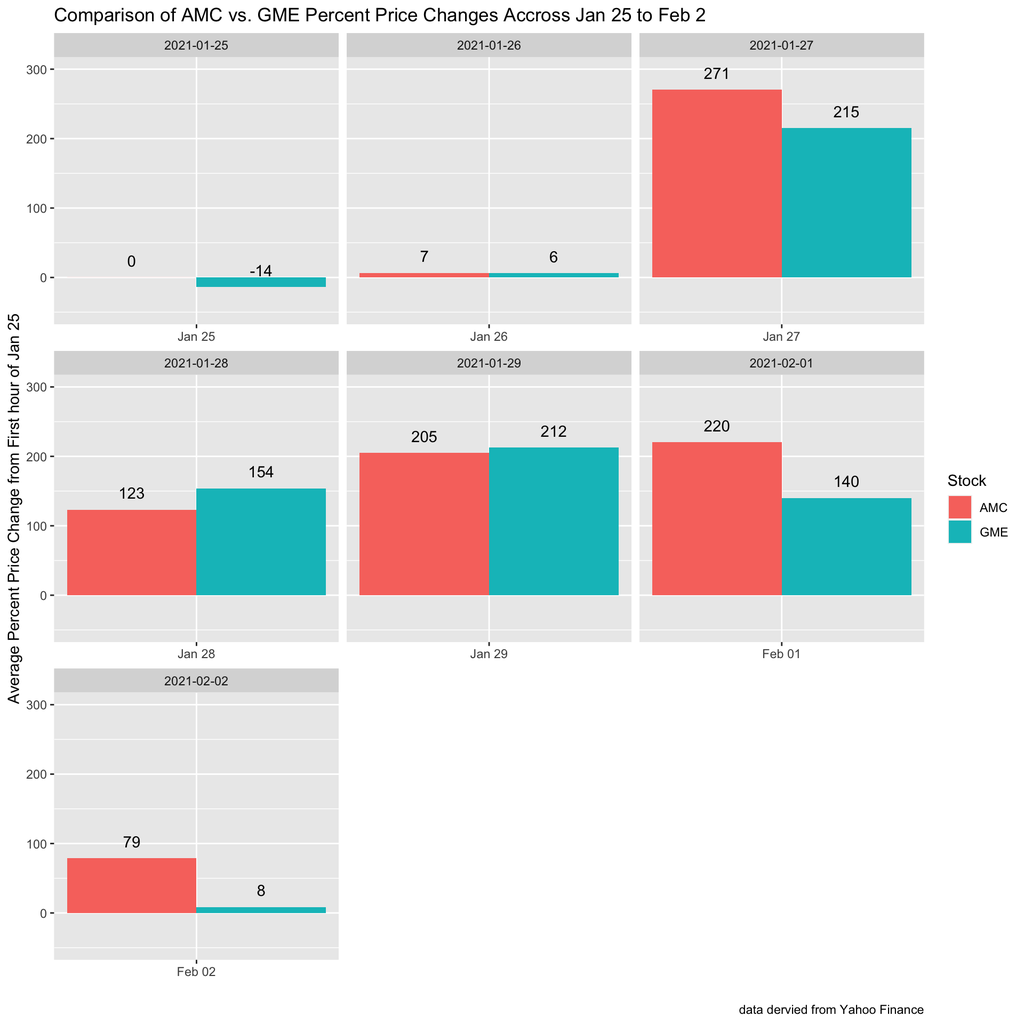

```r
df %>%
  group_by(Date, Stock) %>%
  summarize(Daily_Perc_Change_Avg_Price = mean(Perc_Change_Avg_Price)) %>%
  ggplot(aes(x = Date,
             y = Daily_Perc_Change_Avg_Price,
             fill = Stock)) +
  ylim(-50,300) +
  geom_text(aes(label=round(Daily_Perc_Change_Avg_Price,0)),
            position=position_dodge(width=0.9), vjust=-1) +
  geom_col(position = "dodge") +
  facet_wrap(~Date, ncol = 3, scales = "free_x") +
  labs(y = "Average Percent Price Change from First hour of Jan 25",
       x = "",
       title = "Comparison of AMC vs. GME Percent Price Changes Accross Jan 25 to Feb 2",
       caption = "data dervied from Yahoo Finance")
```

Scatter Plot of GME vs AMC Stock Price w/ regression line overlay:

```r
GME$GMEPrice <- GME$Avg_Price
AMC$AMCPrice <- AMC$Avg_Price
prices <- data.frame(cbind(GME$GMEPrice,AMC$AMCPrice))
colnames(prices) <- c("GME","AMC")
```

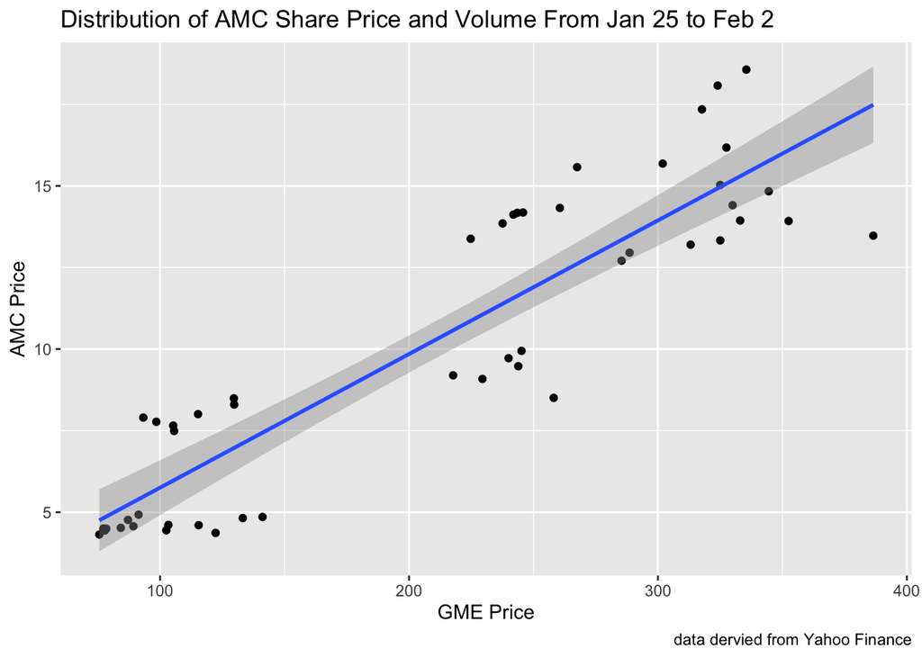

```r
prices %>%
  ggplot(aes(x = GME,
             y = AMC,)) +
  geom_point() +
  geom_smooth(method= "lm") +
  labs(y = "AMC Price",
       x = "GME Price",
       title = "Distribution of AMC Share Price and Volume From Jan 25 to Feb 2",
       caption = "data dervied from Yahoo Finance")
```

```r
prices %>%
  lm(formula = GME ~ AMC) %>%
  summary()
```

```
##
## Call:
## lm(formula = GME ~ AMC, data = .)
##
## Residuals:
##    Min     1Q Median     3Q    Max
## -69.58 -41.02 -11.44  37.83 112.89
##
## Coefficients:
##             Estimate Std. Error t value Pr(>|t|)
## (Intercept)    5.842     15.424   0.379    0.707
## AMC           19.872      1.386  14.333   <2e-16 ***
## ---
## Signif. codes:  0 '***' 0.001 '**' 0.01 '*' 0.05 '.' 0.1 ' ' 1
##
## Residual standard error: 43.46 on 47 degrees of freedom
## Multiple R-squared:  0.8138, Adjusted R-squared:  0.8099
## F-statistic: 205.4 on 1 and 47 DF,  p-value: < 2.2e-16
```